# FE

### DOMAIN:

```
Semiconductor manufacturing process.
```

### CONTEXT:

```
A complex modern semiconductor manufacturing process is normally under constant surveillance via the monitoring of signals/variables collected from sensors and or process measurement points. However, not all of these signals are equally valuable in a specific monitoring system. The measured signals contain a combination of useful information, irrelevant information as well as noise. Engineers typically have a much larger number of signals than are actually required. If we consider each type of signal as a feature, then feature selection may be applied to identify the most relevant signals. The Process Engineers may then use these signals to determine key factors contributing to yield excursions downstream in the process. This will enable an increase in process throughput, decreased time to learning and reduce the per unit production costs. These signals can be used as features to predict the yield type. And by analysing and trying out different combinations of features, essential signals that are impacting the yield type can be identified.
```

### DATA DESCRIPTION:

```
sensor-data.csv : (1567, 592)
The data consists of 1567 examples each with 591 features. The dataset presented in this case represents a selection of such features where each example represents a single production entity with associated measured features and the labels represent a simple pass/fail yield for in house line testing. Target column “ –1” corresponds to a pass and “1” corresponds to a fail and the data time stamp is for that specific test point.
```

### PROJECT OBJECTIVE:

```
We will build a classifier to predict the Pass/Fail yield of a particular process entity and analyse whether all the features are required to build the model or not.
```

### Importing Data Manipulation modules and data visualization modules:

```python
import pandas as pd
import numpy as np
import seaborn as sns
pd. set_option('display.max_rows', 1500)
pd. set_option('display.max_columns', 1500)
import matplotlib.pyplot as plt
```

### Reading the given csv file:

```python
signal = pd.read_csv('signal-data.csv')
```

```python
signal.head()
```

|  | Time | 0 | 1 | 2 | 3 | 4 | 5 | 6 | 7 | 8 | 9 | 10 | 11 | 12 | 13 | 14 | 15 | 16 | 17 | 18 | 19 | 20 | 21 | 22 | 23 | 24 | 25 | 26 | 27 | … |
| --- | --- | --- | --- | --- | --- | --- | --- | --- | --- | --- | --- | --- | --- | --- | --- | --- | --- | --- | --- | --- | --- | --- | --- | --- | --- | --- | --- | --- | --- | --- |
| 0 | 2008-07-19 11:55:00 | 3030.93 | 2564.00 | 2187.7333 | 1411.1265 | 1.3602 | 100.0 | 97.6133 | 0.1242 | 1.5005 | 0.0162 | -0.0034 | 0.9455 | 202.4396 | 0.0 | 7.9558 | 414.8710 | 10.0433 | 0.9680 | 192.3963 | 12.5190 | 1.4026 | -5419.00 | 2916.50 | -4043.75 | 751.00 | 0.8955 | 1.7730 | 3.0490 | … |
| 1 | 2008-07-19 12:32:00 | 3095.78 | 2465.14 | 2230.4222 | 1463.6606 | 0.8294 | 100.0 | 102.3433 | 0.1247 | 1.4966 | -0.0005 | -0.0148 | 0.9627 | 200.5470 | 0.0 | 10.1548 | 414.7347 | 9.2599 | 0.9701 | 191.2872 | 12.4608 | 1.3825 | -5441.50 | 2604.25 | -3498.75 | -1640.25 | 1.2973 | 2.0143 | 7.3900 | … |
| 2 | 2008-07-19 13:17:00 | 2932.61 | 2559.94 | 2186.4111 | 1698.0172 | 1.5102 | 100.0 | 95.4878 | 0.1241 | 1.4436 | 0.0041 | 0.0013 | 0.9615 | 202.0179 | 0.0 | 9.5157 | 416.7075 | 9.3144 | 0.9674 | 192.7035 | 12.5404 | 1.4123 | -5447.75 | 2701.75 | -4047.00 | -1916.50 | 1.3122 | 2.0295 | 7.5788 | … |
| 3 | 2008-07-19 14:43:00 | 2988.72 | 2479.90 | 2199.0333 | 909.7926 | 1.3204 | 100.0 | 104.2367 | 0.1217 | 1.4882 | -0.0124 | -0.0033 | 0.9629 | 201.8482 | 0.0 | 9.6052 | 422.2894 | 9.6924 | 0.9687 | 192.1557 | 12.4782 | 1.4011 | -5468.25 | 2648.25 | -4515.00 | -1657.25 | 1.3137 | 2.0038 | 7.3145 | … |
| 4 | 2008-07-19 15:22:00 | 3032.24 | 2502.87 | 2233.3667 | 1326.5200 | 1.5334 | 100.0 | 100.3967 | 0.1235 | 1.5031 | -0.0031 | -0.0072 | 0.9569 | 201.9424 | 0.0 | 10.5661 | 420.5925 | 10.3387 | 0.9735 | 191.6037 | 12.4735 | 1.3888 | -5476.25 | 2635.25 | -3987.50 | 117.00 | 1.2887 | 1.9912 | 7.2748 | … |

```python
signal.tail()
```

|  | Time | 0 | 1 | 2 | 3 | 4 | 5 | 6 | 7 | 8 | 9 | 10 | 11 | 12 | 13 | 14 | 15 | 16 | 17 | 18 | 19 | 20 | 21 | 22 | 23 | 24 | 25 | 26 | 27 | … |
| --- | --- | --- | --- | --- | --- | --- | --- | --- | --- | --- | --- | --- | --- | --- | --- | --- | --- | --- | --- | --- | --- | --- | --- | --- | --- | --- | --- | --- | --- | --- |
| 1562 | 2008-10-16 15:13:00 | 2899.41 | 2464.36 | 2179.7333 | 3085.3781 | 1.4843 | 100.0 | 82.2467 | 0.1248 | 1.3424 | -0.0045 | -0.0057 | 0.9579 | 203.9867 | 0.0 | 11.7692 | 419.3404 | 10.2397 | 0.9693 | 193.7470 | 12.5373 | 1.4072 | -5418.75 | 2608.0 | -6228.25 | 356.00 | 1.2817 | 1.9540 | 7.0793 | … |
| 1563 | 2008-10-16 20:49:00 | 3052.31 | 2522.55 | 2198.5667 | 1124.6595 | 0.8763 | 100.0 | 98.4689 | 0.1205 | 1.4333 | -0.0061 | -0.0093 | 0.9618 | 204.0173 | 0.0 | 9.1620 | 405.8178 | 10.2285 | 0.9696 | 193.7889 | 12.4020 | 1.3949 | -6408.75 | 2277.5 | -3675.50 | 339.00 | 1.0870 | 1.8023 | 5.1515 | … |
| 1564 | 2008-10-17 05:26:00 | 2978.81 | 2379.78 | 2206.3000 | 1110.4967 | 0.8236 | 100.0 | 99.4122 | 0.1208 | NaN | NaN | NaN | NaN | NaN | NaN | NaN | NaN | NaN | NaN | NaN | 12.4555 | 1.4256 | -5153.25 | 2707.0 | -4102.00 | -1226.00 | 1.2930 | 1.9435 | 7.2315 | … |
| 1565 | 2008-10-17 06:01:00 | 2894.92 | 2532.01 | 2177.0333 | 1183.7287 | 1.5726 | 100.0 | 98.7978 | 0.1213 | 1.4622 | -0.0072 | 0.0032 | 0.9694 | 197.2448 | 0.0 | 9.7354 | 401.9153 | 9.8630 | 0.9740 | 187.3818 | 12.3937 | 1.3868 | -5271.75 | 2676.5 | -4001.50 | 394.75 | 1.2875 | 1.9880 | 7.3255 | … |
| 1566 | 2008-10-17 06:07:00 | 2944.92 | 2450.76 | 2195.4444 | 2914.1792 | 1.5978 | 100.0 | 85.1011 | 0.1235 | NaN | NaN | NaN | NaN | NaN | NaN | NaN | NaN | NaN | NaN | NaN | 12.4790 | 1.4048 | -5319.50 | 2668.0 | -3951.75 | -425.00 | 1.3020 | 2.0085 | 7.3395 | … |

```python
signal.shape
```

```
(1567, 592)
```

### Checking for null values in the dataframe:

```python
signal.isna().sum()
```

```
Time            0
0               6
1               7
2              14
3              14
4              14
5              14
6              14
7               9
8               2
9               2
10              2
11              2
12              2
13              3
```

[output cut: 578 more lines]

```python
signal.isna().apply(pd.value_counts)
```

|  | Time | 0 | 1 | 2 | 3 | 4 | 5 | 6 | 7 | 8 | 9 | 10 | 11 | 12 | 13 | 14 | 15 | 16 | 17 | 18 | 19 | 20 | 21 | 22 | 23 | 24 | 25 | 26 | 27 | … |
| --- | --- | --- | --- | --- | --- | --- | --- | --- | --- | --- | --- | --- | --- | --- | --- | --- | --- | --- | --- | --- | --- | --- | --- | --- | --- | --- | --- | --- | --- | --- |
| False | 1567.0 | 1561 | 1560 | 1553 | 1553 | 1553 | 1553 | 1553 | 1558 | 1565 | 1565 | 1565 | 1565 | 1565 | 1564 | 1564 | 1564 | 1564 | 1564 | 1564 | 1557 | 1567.0 | 1565 | 1565 | 1565 | 1565 | 1565 | 1565 | 1565 | … |
| True | NaN | 6 | 7 | 14 | 14 | 14 | 14 | 14 | 9 | 2 | 2 | 2 | 2 | 2 | 3 | 3 | 3 | 3 | 3 | 3 | 10 | NaN | 2 | 2 | 2 | 2 | 2 | 2 | 2 | … |

### Dropping Column "Time":

```python
signal = signal.drop('Time', axis=1)
```

### Replacing all the null or NaN values in the dataframe with their respective column means:

```python
for i in signal.columns:
    signal[i] = signal[i].replace(np.nan, signal[i].mean())
```

### Checking for the correlation between the target column and the independent columns:

```python
corr_with_tagert=[]
indep_cols = signal.drop('Pass/Fail', axis = 1).columns

for cols in indep_cols:
    corr_with_tagert.append(abs(signal['Pass/Fail'].corr(signal[cols])))

corr_table = pd.DataFrame([indep_cols, corr_with_tagert], index = ['Independent Column', 'Corr with Target']).T

display(corr_table)
```

|  | Independent Column | Corr with Target |
| --- | --- | --- |
| 0 | 0 | 0.025141 |
| 1 | 1 | 0.002603 |
| 2 | 2 | 0.000957 |
| 3 | 3 | 0.024623 |
| 4 | 4 | 0.013756 |
| 5 | 5 | NaN |
| 6 | 6 | 0.016239 |
| 7 | 7 | 0.012991 |
| 8 | 8 | 0.028016 |
| 9 | 9 | 0.031191 |
| 10 | 10 | 0.033639 |
| 11 | 11 | 0.03262 |
| 12 | 12 | 0.005969 |
| 13 | 13 | NaN |
| 14 | 14 | 0.068975 |
| 15 | 15 | 0.002884 |
| 16 | 16 | 0.002356 |
| 17 | 17 | 0.009697 |
| 18 | 18 | 0.008853 |
| 19 | 19 | 0.030513 |
| 20 | 20 | 0.023253 |
| 21 | 21 | 0.107997 |
| 22 | 22 | 0.07338 |
| 23 | 23 | 0.012873 |
| 24 | 24 | 0.018297 |
| 25 | 25 | 0.036379 |
| 26 | 26 | 0.081146 |
| 27 | 27 | 0.029206 |
| 28 | 28 | 0.106767 |
| 29 | 29 | 0.017115 |

[output cut: 560 more lines]

### We can see that a lot of columns have null correlation with the target "Pass/Fail". And many columns have very less correlation(For Example:0.002) with the target. So we will select only those columns where the correlation with target is above 0.09.

```python
strong_corr = corr_table[corr_table['Corr with Target'] > 0.09 ]
```

```python
strong_corr.head(20)
```

|  | Independent Column | Corr with Target |
| --- | --- | --- |
| 21 | 21 | 0.107997 |
| 28 | 28 | 0.106767 |
| 59 | 59 | 0.155771 |
| 103 | 103 | 0.151196 |
| 124 | 124 | 0.093974 |
| 129 | 129 | 0.103351 |
| 163 | 163 | 0.099876 |
| 210 | 210 | 0.102488 |
| 295 | 295 | 0.091831 |
| 298 | 298 | 0.102055 |
| 348 | 348 | 0.130108 |
| 430 | 430 | 0.109569 |
| 431 | 431 | 0.120304 |
| 434 | 434 | 0.111609 |
| 435 | 435 | 0.108573 |
| 436 | 436 | 0.106426 |
| 510 | 510 | 0.131587 |

```python
cols_select=[]
for i in strong_corr['Independent Column']:
    cols_select.append(i)
```

```python
cols_select
```

```
['21',
 '28',
 '59',
 '103',
 '124',
 '129',
 '163',
 '210',
 '295',
 '298',
 '348',
 '430',
 '431',
 '434',
 '435',
 '436',
 '510']
```

### Selecting only the columns in the list cols_select from signal dataframe:

```python
signal = signal[['21','28','59','103', '124', '129','163', '210', '295', '298', '348', '430', '431', '434', '435',
                 '436', '510', 'Pass/Fail']]
```

```python
signal.head()
```

|  | 21 | 28 | 59 | 103 | 124 | 129 | 163 | 210 | 295 | 298 | 348 | 430 | 431 | 434 | 435 | 436 | 510 | Pass/Fail |
| --- | --- | --- | --- | --- | --- | --- | --- | --- | --- | --- | --- | --- | --- | --- | --- | --- | --- | --- |
| 0 | -5419.00 | 64.2333 | -1.7264 | -0.0042 | 15.93 | -0.0473 | 0.090 | 0.0772 | 398.3185 | 0.0373 | 0.0215 | 18.7673 | 33.1562 | 10.0503 | 2.7073 | 3.1158 | 64.6707 | -1 |
| 1 | -5441.50 | 68.4222 | 0.8073 | -0.0045 | 15.88 | -0.0946 | 0.112 | 0.0566 | 26.5879 | 0.0502 | 0.0142 | 10.4383 | 2.2655 | 8.6336 | 5.7093 | 1.6779 | 141.4365 | -1 |
| 2 | -5447.75 | 67.1333 | 23.8245 | -0.0026 | 15.95 | -0.1892 | 0.187 | 0.0339 | 329.6406 | 0.0800 | 0.0105 | 10.3162 | 29.1663 | 14.2503 | 5.7650 | 0.8972 | 240.7767 | 1 |
| 3 | -5468.25 | 62.9333 | 24.3791 | -0.0059 | 15.59 | 0.2838 | 0.068 | 0.1248 | 157.0889 | 0.0285 | 0.0407 | 15.7089 | 13.4051 | 5.1760 | 5.3899 | 1.3671 | 113.5593 | -1 |
| 4 | -5476.25 | 62.8333 | -12.2945 | -0.0045 | 15.71 | -0.5677 | 0.147 | 0.0915 | 128.0296 | 0.0755 | 0.0246 | 12.7642 | 10.7390 | 11.4064 | 2.0088 | 1.5533 | 148.0663 | -1 |

```python
signal.shape
```

```
(1567, 18)
```

```python
signal.isna().sum()
```

```
21           0
28           0
59           0
103          0
124          0
129          0
163          0
210          0
295          0
298          0
348          0
430          0
431          0
434          0
435          0
436          0
510          0
Pass/Fail    0
dtype: int64
```

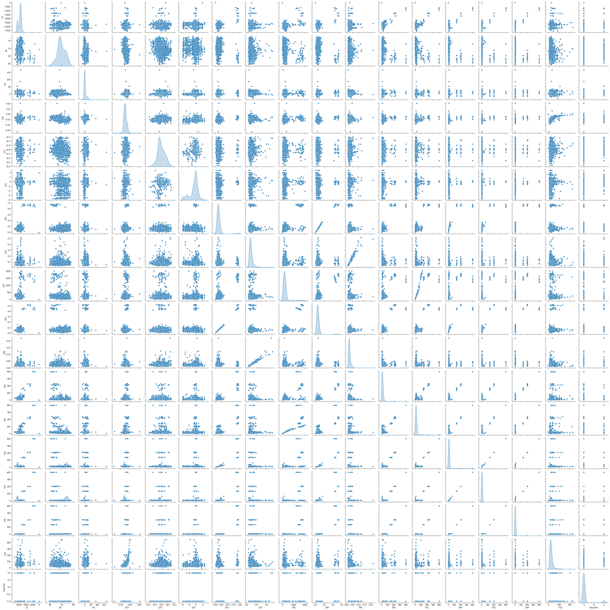

```python
sns.pairplot(signal, diag_kind = 'kde');
```

```python
signal.describe()
```

|  | 21 | 28 | 59 | 103 | 124 | 129 | 163 | 210 | 295 | 298 | 348 | 430 | 431 | 434 | 435 | 436 | 510 | Pass/Fail |
| --- | --- | --- | --- | --- | --- | --- | --- | --- | --- | --- | --- | --- | --- | --- | --- | --- | --- | --- |
| count | 1567.000000 | 1567.000000 | 1567.000000 | 1567.000000 | 1567.000000 | 1567.000000 | 1567.000000 | 1567.000000 | 1567.000000 | 1567.000000 | 1567.000000 | 1567.00000 | 1567.000000 | 1567.000000 | 1567.000000 | 1567.000000 | 1567.000000 | 1567.000000 |
| mean | -5618.393610 | 69.499532 | 2.960241 | -0.009789 | 15.794705 | -0.554228 | 0.140204 | 0.088866 | 252.999118 | 0.063804 | 0.024706 | 18.42160 | 22.358305 | 14.733945 | 9.370666 | 7.513266 | 55.763508 | -0.867262 |
| std | 626.421781 | 3.458970 | 9.510891 | 0.003063 | 0.113815 | 1.216967 | 0.121911 | 0.041741 | 283.349590 | 0.064184 | 0.011771 | 36.03705 | 36.372159 | 34.087066 | 34.347834 | 34.535729 | 37.667659 | 0.498010 |
| min | -7150.250000 | 59.400000 | -28.988200 | -0.032900 | 15.430000 | -3.779000 | 0.000000 | 0.031900 | 0.000000 | 0.000000 | 0.010300 | 0.00000 | 0.000000 | 0.000000 | 0.000000 | 0.000000 | 0.000000 | -1.000000 |
| 25% | -5932.625000 | 67.383350 | -1.855450 | -0.011800 | 15.730000 | -0.898800 | 0.091000 | 0.065900 | 130.263200 | 0.040700 | 0.018200 | 7.00620 | 11.069050 | 7.551150 | 3.495000 | 1.951700 | 35.324400 | -1.000000 |
| 50% | -5523.250000 | 69.155600 | 0.973600 | -0.010100 | 15.780000 | -0.141900 | 0.120000 | 0.080300 | 195.840700 | 0.052800 | 0.022800 | 11.10960 | 16.381700 | 10.200500 | 4.555700 | 2.766400 | 47.058800 | -1.000000 |
| 75% | -5356.625000 | 72.255550 | 4.337700 | -0.008200 | 15.870000 | 0.047300 | 0.154000 | 0.099050 | 273.865150 | 0.069200 | 0.027300 | 17.56015 | 21.825750 | 12.764700 | 5.826950 | 3.826400 | 64.228450 | -1.000000 |
| max | 0.000000 | 77.900000 | 168.145500 | 0.020300 | 16.100000 | 2.458000 | 0.957000 | 0.516400 | 2005.874400 | 0.526400 | 0.220000 | 400.00000 | 400.000000 | 400.000000 | 400.000000 | 400.000000 | 451.485100 | 1.000000 |

```python
signal.corr()
```

|  | 21 | 28 | 59 | 103 | 124 | 129 | 163 | 210 | 295 | 298 | 348 | 430 | 431 | 434 | 435 | 436 | 510 | Pass/Fail |
| --- | --- | --- | --- | --- | --- | --- | --- | --- | --- | --- | --- | --- | --- | --- | --- | --- | --- | --- |
| 21 | 1.000000 | 0.006597 | -0.026307 | 0.022183 | -0.101226 | -0.078437 | 0.601960 | -0.003069 | 0.383166 | 0.621514 | -0.001649 | 0.674305 | 0.595582 | 0.631860 | 0.644550 | 0.638651 | 0.059851 | 0.107997 |
| 28 | 0.006597 | 1.000000 | -0.257863 | -0.337005 | -0.222540 | -0.194453 | -0.153056 | -0.106065 | -0.222066 | -0.165475 | -0.124501 | -0.182528 | -0.219346 | -0.190581 | -0.187473 | -0.196796 | -0.243887 | -0.106767 |
| 59 | -0.026307 | -0.257863 | 1.000000 | 0.287722 | 0.083619 | 0.190543 | 0.086903 | 0.137609 | 0.096388 | 0.089933 | 0.142836 | 0.072240 | 0.095420 | 0.091144 | 0.085272 | 0.084576 | 0.217680 | 0.155771 |
| 103 | 0.022183 | -0.337005 | 0.287722 | 1.000000 | 0.124815 | 0.277127 | 0.135279 | 0.126764 | 0.163819 | 0.145362 | 0.153242 | 0.148998 | 0.169148 | 0.150095 | 0.148186 | 0.148108 | 0.609697 | 0.151196 |
| 124 | -0.101226 | -0.222540 | 0.083619 | 0.124815 | 1.000000 | 0.190298 | 0.005731 | 0.073487 | 0.063806 | 0.004582 | 0.095236 | -0.020512 | 0.027108 | 0.005188 | -0.004988 | -0.000496 | 0.083073 | 0.093974 |
| 129 | -0.078437 | -0.194453 | 0.190543 | 0.277127 | 0.190298 | 1.000000 | 0.019882 | 0.085650 | 0.116214 | 0.026033 | 0.113664 | 0.053295 | 0.088214 | 0.050707 | 0.053475 | 0.055148 | 0.149298 | 0.103351 |
| 163 | 0.601960 | -0.153056 | 0.086903 | 0.135279 | 0.005731 | 0.019882 | 1.000000 | 0.036149 | 0.655155 | 0.993392 | 0.041687 | 0.826769 | 0.811319 | 0.876364 | 0.844632 | 0.839704 | 0.132016 | 0.099876 |
| 210 | -0.003069 | -0.106065 | 0.137609 | 0.126764 | 0.073487 | 0.085650 | 0.036149 | 1.000000 | 0.047442 | 0.039999 | 0.949733 | 0.030914 | 0.048505 | 0.046410 | 0.046619 | 0.046244 | 0.066699 | 0.102488 |
| 295 | 0.383166 | -0.222066 | 0.096388 | 0.163819 | 0.063806 | 0.116214 | 0.655155 | 0.047442 | 1.000000 | 0.669677 | 0.058700 | 0.601822 | 0.828019 | 0.612419 | 0.602110 | 0.606385 | 0.142075 | 0.091831 |
| 298 | 0.621514 | -0.165475 | 0.089933 | 0.145362 | 0.004582 | 0.026033 | 0.993392 | 0.039999 | 0.669677 | 1.000000 | 0.044927 | 0.842164 | 0.825372 | 0.885728 | 0.860458 | 0.857012 | 0.141004 | 0.102055 |
| 348 | -0.001649 | -0.124501 | 0.142836 | 0.153242 | 0.095236 | 0.113664 | 0.041687 | 0.949733 | 0.058700 | 0.044927 | 1.000000 | 0.037779 | 0.057312 | 0.050981 | 0.050440 | 0.049986 | 0.079128 | 0.130108 |
| 430 | 0.674305 | -0.182528 | 0.072240 | 0.148998 | -0.020512 | 0.053295 | 0.826769 | 0.030914 | 0.601822 | 0.842164 | 0.037779 | 1.000000 | 0.899213 | 0.948040 | 0.951673 | 0.953723 | 0.138906 | 0.109569 |
| 431 | 0.595582 | -0.219346 | 0.095420 | 0.169148 | 0.027108 | 0.088214 | 0.811319 | 0.048505 | 0.828019 | 0.825372 | 0.057312 | 0.899213 | 1.000000 | 0.933359 | 0.929544 | 0.932598 | 0.139180 | 0.120304 |
| 434 | 0.631860 | -0.190581 | 0.091144 | 0.150095 | 0.005188 | 0.050707 | 0.876364 | 0.046410 | 0.612419 | 0.885728 | 0.050981 | 0.948040 | 0.933359 | 1.000000 | 0.993665 | 0.992333 | 0.128726 | 0.111609 |
| 435 | 0.644550 | -0.187473 | 0.085272 | 0.148186 | -0.004988 | 0.053475 | 0.844632 | 0.046619 | 0.602110 | 0.860458 | 0.050440 | 0.951673 | 0.929544 | 0.993665 | 1.000000 | 0.996216 | 0.128324 | 0.108573 |
| 436 | 0.638651 | -0.196796 | 0.084576 | 0.148108 | -0.000496 | 0.055148 | 0.839704 | 0.046244 | 0.606385 | 0.857012 | 0.049986 | 0.953723 | 0.932598 | 0.992333 | 0.996216 | 1.000000 | 0.127060 | 0.106426 |
| 510 | 0.059851 | -0.243887 | 0.217680 | 0.609697 | 0.083073 | 0.149298 | 0.132016 | 0.066699 | 0.142075 | 0.141004 | 0.079128 | 0.138906 | 0.139180 | 0.128726 | 0.128324 | 0.127060 | 1.000000 | 0.131587 |
| Pass/Fail | 0.107997 | -0.106767 | 0.155771 | 0.151196 | 0.093974 | 0.103351 | 0.099876 | 0.102488 | 0.091831 | 0.102055 | 0.130108 | 0.109569 | 0.120304 | 0.111609 | 0.108573 | 0.106426 | 0.131587 | 1.000000 |

### Plotting the relationship between column 435 vs 434 because we can see that their correlation is strong i.e. 0.993665.

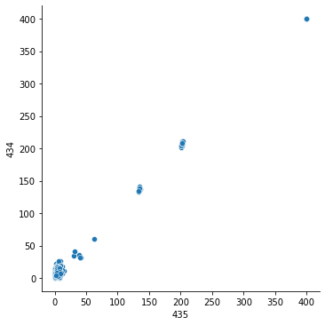

```python
sns.relplot(x='435', y='434', data=signal);
```

### Plotting the relationship between column 431 vs 434 because we can see that their correlation is strong i.e. 0.933359.

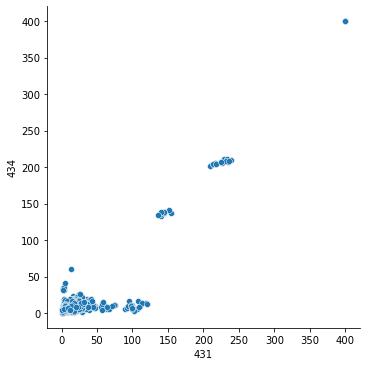

```python
sns.relplot(x='431', y='434', data=signal);
```

### Plotting the relationship between column 21 vs 430 because we can see that their correlation is strong i.e. 0.674305.

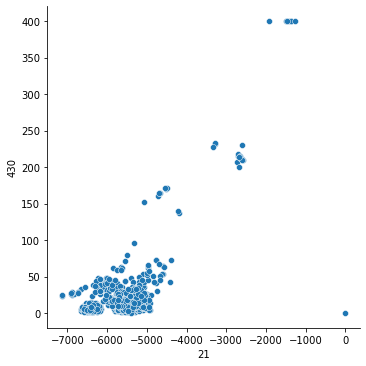

```python
sns.relplot(x='21', y='430', data=signal);
```

### Plotting the relationship between column 103 vs 510 because we can see that their correlation is strong i.e. 0.609697.

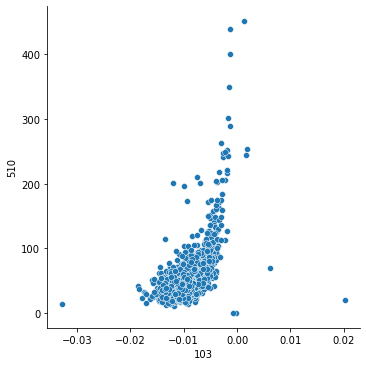

```python
sns.relplot(x='103', y='510', data=signal);
```

### Checking the distribution in the target column and replacing -1 with 1(Pass) and 1 with 0(Fail).

```python
# Checking the distribution of target variable
display(signal['Pass/Fail'].value_counts(), signal['Pass/Fail'].value_counts(normalize = True)*100)
```

```
-1    1463
 1     104
Name: Pass/Fail, dtype: int64
```

```
-1    93.363114
 1     6.636886
Name: Pass/Fail, dtype: float64
```

-1 corresponds to pass and 1 corresponds to fail. Lets replace these values with 1 and 0 respectively.

```python
signal['Pass/Fail'] = signal['Pass/Fail'].replace({-1: 1, 1:0})
```

```python
# Checking the distribution of target variable
display(signal['Pass/Fail'].value_counts(), signal['Pass/Fail'].value_counts(normalize = True)*100)
```

```
1    1463
0     104
Name: Pass/Fail, dtype: int64
```

```
1    93.363114
0     6.636886
Name: Pass/Fail, dtype: float64
```

### Bifurcating the independent columns(X) and target column(y):

```python
X = signal.drop('Pass/Fail', axis =1)
y = signal['Pass/Fail']
```

```python
from sklearn.model_selection import train_test_split

X_train, X_test, y_train, y_test = train_test_split(X, y, test_size=0.25, stratify = y, random_state=1)
```

### Using StandardScaler() to normalize the data:

```python
from sklearn.preprocessing import StandardScaler

scaler = StandardScaler()

X_train = scaler.fit_transform(X_train)
X_test = scaler.transform(X_test)
```

### We will use Logistic Regression, Decission Tree Classifier and Random Forest Classifier to predict the target for the given data set:

```python
from sklearn.linear_model import LogisticRegression #importing logistic regression

lr = LogisticRegression()

lr.fit(X_train, y_train)

pred = lr.predict(X_test)  # Predictions from logistic regression
score1 = lr.score(X_test, y_test)
score1
```

```
0.9336734693877551
```

```python
from sklearn.tree import DecisionTreeClassifier

X_train, X_test, y_train, y_test = train_test_split(X, y, random_state = 1)

dt = DecisionTreeClassifier()

dt.fit(X_train, y_train)

score2 = dt.score(X_test, y_test)
pred = dt.predict(X_test)

print(f"Decision tree acccuracy score: {score2}")
```

```
Decision tree acccuracy score: 0.8571428571428571
```

```python
from sklearn.ensemble import RandomForestClassifier

rf = RandomForestClassifier()

rf.fit(X_train, y_train)

score3 = rf.score(X_test, y_test)

print(f'Random Forest accuracy score = {score3}')
```

```
Random Forest accuracy score = 0.9336734693877551
```

```python
pd.Series(dt.feature_importances_, X_train.columns ).sort_values(ascending= False) #Features selected while creating the decision tree
```

```
59     0.160070
210    0.119007
431    0.076913
295    0.076812
434    0.063340
21     0.060718
28     0.057550
510    0.055460
430    0.054876
124    0.051585
103    0.044892
129    0.041239
348    0.040290
435    0.039507
298    0.030963
436    0.026778
163    0.000000
dtype: float64
```

### Using cross validation with above mentioned model:

```python
from sklearn.model_selection import cross_val_score
#For Decision Tree dt
score4 = cross_val_score(dt, X, y, cv = 10).mean()
print(f'Cross validation score of Decision tree = {score4}')
```

```
Cross validation score of Decision tree = 0.8322758451739343
```

```python
score5 = cross_val_score(rf, X, y, cv = 10).mean()
print(f'Cross validation score of Random forest = {score5}')
```

```
Cross validation score of Random forest = 0.916438020578148
```

### Model Tuning For Random Forest Classifier

```python
from sklearn.model_selection import GridSearchCV

parameters = {'bootstrap': [True],
 'max_depth': [10, 20, 30, 40, 50],
 'max_features': ['auto', 'sqrt'],
 'min_samples_leaf': [1, 2, 4, 8],
 'n_estimators': [100]}


clf = GridSearchCV(RandomForestClassifier(), parameters, cv = 5, verbose = 2, n_jobs= 4)
clf.fit(X, y)

clf.best_params_
```

```
Fitting 5 folds for each of 40 candidates, totalling 200 fits
```

```
{'bootstrap': True,
 'max_depth': 10,
 'max_features': 'sqrt',
 'min_samples_leaf': 8,
 'n_estimators': 100}
```

```python
rf = RandomForestClassifier(bootstrap= True,
 max_depth= 30,
 max_features= 'sqrt',
 min_samples_leaf= 1,
 n_estimators= 100)

rf.fit(X_train, y_train)

score6 = cross_val_score(rf, X_train, y_train, cv = 5).mean()


score6
```

```
0.9310638297872341
```

```python
data = {'Technique' : ['Logistic Regression', 'Decision tree',
                       'Random forest', 'DT CV','RF CV','Tuned RF CV'],
       'Score' : [score1,score2, score3, score4, score5, score6] }

result = pd.DataFrame(data)
```

```python
result
```

|  | Technique | Score |
| --- | --- | --- |
| 0 | Logistic Regression | 0.933673 |
| 1 | Decision tree | 0.857143 |
| 2 | Random forest | 0.933673 |
| 3 | DT CV | 0.832276 |
| 4 | RF CV | 0.916438 |
| 5 | Tuned RF CV | 0.931064 |

### Importing PCA for dimensionality reduction:

```python
from sklearn.decomposition import PCA
```

```python
covMatrix = np.cov(X_train,rowvar=False)
print(covMatrix)
```

```
[[ 4.22316154e+05 -2.87491287e+01 -1.24773981e+02  7.29030010e-02
  -5.37504375e+00 -4.82607570e+01  5.06510092e+01  2.10323035e-01
   7.68306211e+04  2.76639729e+01  6.29441964e-02  1.69595056e+04
   1.53626635e+04  1.52773921e+04  1.56748269e+04  1.56341868e+04
   1.64068563e+03]
 [-2.87491287e+01  1.22275154e+01 -8.57278460e+00 -3.71287675e-03
  -9.03687542e-02 -7.44272871e-01 -7.20757560e-02 -1.62596635e-02
  -2.22777631e+02 -4.11882031e-02 -5.30280076e-03 -2.63059561e+01
  -2.93293454e+01 -2.45914106e+01 -2.42875754e+01 -2.54514715e+01
  -3.33609774e+01]
 [-1.24773981e+02 -8.57278460e+00  8.88178698e+01  8.44609800e-03
   7.74198286e-02  2.28269827e+00  9.01806955e-02  5.05442066e-02
   2.27289242e+02  4.92516786e-02  1.52127181e-02  2.36943620e+01
   3.04541671e+01  2.75901466e+01  2.57534401e+01  2.57204007e+01
   7.68489348e+01]
 [ 7.29030010e-02 -3.71287675e-03  8.44609800e-03  9.75390084e-06
   5.46570720e-05  1.02825863e-03  6.00553424e-05  1.58310749e-05
   1.36739557e-01  3.36697067e-05  5.44917452e-06  1.91507369e-02
   1.98728502e-02  1.78594149e-02  1.74913573e-02  1.75414321e-02
   6.87288688e-02]
 [-5.37504375e+00 -9.03687542e-02  7.74198286e-02  5.46570720e-05
   1.27058476e-02  2.82050478e-02  1.13916550e-04  5.24337466e-04
   1.66053001e+00  5.19890840e-05  1.82314955e-04 -4.47526108e-02
   8.42652338e-02  1.80837026e-02 -2.30983643e-02 -4.36336659e-03
   4.39528889e-01]
 [-4.82607570e+01 -7.44272871e-01  2.28269827e+00  1.02825863e-03
   2.82050478e-02  1.44545550e+00  3.13916010e-03  3.45548460e-03
   3.85847992e+01  2.19266043e-03  1.35438635e-03  2.42601827e+00
   3.89531712e+00  2.26454173e+00  2.32196581e+00  2.42999529e+00
   6.62240093e+00]
 [ 5.06510092e+01 -7.20757560e-02  9.01806955e-02  6.00553424e-05
   1.13916550e-04  3.13916010e-03  1.57593963e-02  2.94849156e-04
   2.46821281e+01  8.31498291e-03  9.31389742e-05  4.00936854e+00
   3.97894131e+00  4.00168248e+00  3.90217658e+00  3.90294064e+00
   7.02195875e-01]
 [ 2.10323035e-01 -1.62596635e-02  5.05442066e-02  1.58310749e-05
   5.24337466e-04  3.45548460e-03  2.94849156e-04  1.82141263e-03
   8.21689656e-01  1.65652408e-04  4.97216557e-04  6.48572758e-02
   9.87678676e-02  8.81519874e-02  8.68151320e-02  8.60719408e-02
   1.29750684e-01]
```

[output cut: 30 more lines]

```
 [ 1.56748269e+04 -2.42875754e+01  2.57534401e+01  1.74913573e-02
  -2.30983643e-02  2.32196581e+00  3.90217658e+00  8.68151320e-02
   6.58942968e+03  2.10340559e+00  2.58895392e-02  1.33268299e+03
   1.31294981e+03  1.31193569e+03  1.33074889e+03  1.33373316e+03
   2.00412596e+02]
 [ 1.56341868e+04 -2.54514715e+01  2.57204007e+01  1.75414321e-02
  -4.36336659e-03  2.42999529e+00  3.90294064e+00  8.60719408e-02
   6.66093328e+03  2.10754495e+00  2.55516562e-02  1.34277790e+03
   1.32368179e+03  1.31759706e+03  1.33373316e+03  1.34583143e+03
   2.00296168e+02]
 [ 1.64068563e+03 -3.33609774e+01  7.68489348e+01  6.87288688e-02
   4.39528889e-01  6.62240093e+00  7.02195875e-01  1.29750684e-01
   1.36905025e+03  3.96640140e-01  4.25736259e-02  2.33091601e+02
   2.06172362e+02  1.98801865e+02  2.00412596e+02  2.00296168e+02
   1.33736198e+03]]
```

```python
pca = PCA(n_components=17)
pca.fit(X_train)
```

```
PCA(n_components=17)
```

```python
print(pca.explained_variance_)
```

```
[4.42187183e+05 6.70538901e+04 2.36497730e+03 1.29022071e+03
 8.85785676e+01 8.19690405e+01 2.27774309e+01 1.04014265e+01
 9.15118331e+00 4.08817149e+00 1.32361692e+00 1.14975436e-02
 1.88460240e-03 8.88883787e-04 2.68648018e-05 1.43923123e-05
 5.42886716e-06]
```

```python
print(pca.components_)
```

```
[[ 9.73445130e-01 -1.81733304e-04 -1.53417458e-04  2.34733053e-07
  -1.10307063e-05 -8.65263461e-05  1.25070128e-04  8.94971400e-07
   2.11800164e-01  6.82459813e-05  2.76093233e-07  4.12498376e-02
   3.87944343e-02  3.73890037e-02  3.82460214e-02  3.81944683e-02
   4.37209622e-03]
 [-2.21639966e-01 -3.23587652e-03  3.82586492e-03  1.82472280e-06
   4.18691396e-05  7.29152516e-04  2.05224343e-04  1.15459797e-05
   9.65997046e-01  1.10456760e-04  3.69799850e-06  4.95379505e-02
   8.68561495e-02  5.07760098e-02  4.88086640e-02  5.00099670e-02
   1.55000771e-02]
 [-5.64468388e-02 -1.21615243e-02  1.97923829e-02  1.17182273e-05
   6.29165297e-05  1.72345608e-03  1.00131047e-03  3.29036532e-05
  -1.40123187e-01  5.25493940e-04  9.64285449e-06  4.43101169e-01
   3.34746775e-01  4.57702612e-01  4.62816798e-01  4.67027258e-01
   1.62590817e-01]
 [ 8.50747828e-03 -2.01324123e-02  5.54681759e-02  4.89286275e-05
   3.12172890e-04  4.31851075e-03 -1.07421335e-04  8.30781392e-05
   7.46693085e-03 -4.03193765e-05  2.76800609e-05 -5.25915663e-02
  -6.96827982e-02 -8.08551890e-02 -8.08451442e-02 -8.30829584e-02
   9.84262781e-01]
 [ 4.44669038e-03 -2.63681651e-02  5.17895463e-01  2.54362647e-05
   5.61305029e-04  9.41509900e-03  9.05361133e-05  4.33484463e-04
  -9.20338554e-03  1.56016786e-05  1.17312601e-04 -7.62695340e-01
   2.03261485e-01  2.22855929e-01  1.84795454e-01  1.54824919e-01
  -9.54305403e-03]
 [-6.70154731e-04 -7.68998081e-02  8.49130229e-01  4.16804530e-05
   3.05225871e-04  1.89049658e-02  7.10409666e-05  3.01267122e-04
   4.22365069e-03  6.17588759e-05  9.64206395e-05  4.56504910e-01
  -1.34207481e-01 -1.23854684e-01 -1.22865992e-01 -1.08354362e-01
  -6.40570136e-02]
 [-3.99930967e-06 -4.86708161e-03 -7.01477853e-03 -1.60597923e-05
  -6.61397353e-05 -1.02016767e-02  8.14428678e-03  3.38061541e-04
   4.66731430e-02  4.49625558e-03  7.25127444e-05 -6.23349261e-02
  -9.00109733e-01  2.64554160e-01  2.85539419e-01  1.78624873e-01
  -6.80405482e-03]
 [-8.68344494e-04  9.17189870e-01  6.88030350e-02 -1.13926968e-04
  -5.76338592e-03 -3.70106940e-02  4.81213690e-03 -7.01115931e-04
   4.05643743e-04  1.86195503e-03 -2.22022010e-04  3.64151086e-02
   9.86989790e-03  2.85956538e-01 -4.79830767e-02 -2.58578867e-01
   1.54194392e-02]
```

[output cut: 30 more lines]

```
 [ 1.80397575e-06 -1.16476322e-04  1.11079941e-05 -2.97149605e-02
  -1.86975434e-04  1.12762187e-04  4.55873100e-01 -6.78863083e-03
   2.09528944e-05 -8.89021856e-01  2.98228356e-02 -3.65714815e-05
  -2.99451775e-04 -7.79128600e-04  3.06619963e-04  7.31464859e-04
   1.06994036e-05]
 [ 1.80364863e-08  4.25503770e-05 -4.56329013e-06  4.83370216e-02
  -2.24821702e-03 -2.22828530e-04 -1.61952377e-02 -2.63756995e-01
   1.78025480e-06  2.43963703e-02  9.62929489e-01 -8.20066251e-06
  -3.44493479e-05  4.51197614e-05 -2.81494137e-05  2.54452709e-05
  -4.51863749e-06]
 [ 2.41777338e-07  1.20788846e-04 -3.15074406e-05  9.98380077e-01
  -6.44092417e-04 -3.57058367e-04  1.14731238e-02  1.00868853e-02
   2.91265254e-06 -2.91212202e-02 -4.64244861e-02 -2.31187720e-06
  -4.79038825e-05 -5.87778748e-06 -4.10362198e-06  5.15184854e-05
  -4.31101663e-05]]
```

```python
print(pca.explained_variance_ratio_)
```

```
[8.61770849e-01 1.30680151e-01 4.60906280e-03 2.51448853e-03
 1.72629218e-04 1.59748026e-04 4.43905357e-05 2.02711577e-05
 1.78345807e-05 7.96736575e-06 2.57957381e-06 2.24073611e-08
 3.67286858e-09 1.73233003e-09 5.23563412e-11 2.80489251e-11
 1.05802240e-11]
```

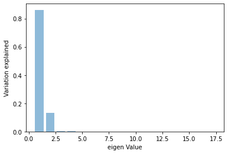

```python
plt.bar(list(range(1,18)),pca.explained_variance_ratio_,alpha=0.5, align='center')
plt.ylabel('Variation explained')
plt.xlabel('eigen Value')
plt.show()
```

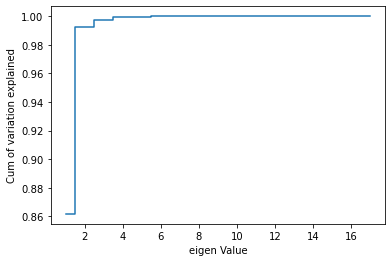

```python
plt.step(list(range(1,18)),np.cumsum(pca.explained_variance_ratio_), where='mid')
plt.ylabel('Cum of variation explained')
plt.xlabel('eigen Value')
plt.show()
```

### From the above graph we can see that with 6 components we can explain more than 95% of the data.

```python
pca = PCA(6)
pca.fit(X_train)
```

```
PCA(n_components=6)
```

```python
X_train_pca = pca.transform(X_train)  # PCs for the train data
X_test_pca = pca.transform(X_test)    # PCs for the test data

X_train_pca.shape, X_test_pca.shape
```

```
((1175, 6), (392, 6))
```

```python
pca.explained_variance_
```

```
array([4.42187183e+05, 6.70538901e+04, 2.36497730e+03, 1.29022071e+03,
       8.85785676e+01, 8.19690405e+01])
```

```python
lr = LogisticRegression(random_state=1, multi_class = 'auto', solver = 'lbfgs', n_jobs=-1, max_iter = 10000)
model_lr = lr.fit(X_train_pca, y_train)
score7 = lr.score(X_test_pca, y_test)


dt = DecisionTreeClassifier()
dt.fit(X_train_pca, y_train)
score8 = dt.score(X_test_pca, y_test)

rf = RandomForestClassifier(bootstrap = True, max_depth = 30, max_features ='auto', min_samples_leaf = 1, n_estimators = 100)
rf.fit(X_train_pca, y_train)
score9 = rf.score(X_test_pca, y_test)
```

```python
lr = LogisticRegression(random_state=1, multi_class = 'auto', solver = 'lbfgs', n_jobs=-1, max_iter = 10000)
score10 = cross_val_score(lr,X_train_pca, y_train , cv = 5).mean()

dt = DecisionTreeClassifier()
score11 = cross_val_score(dt, X_train_pca, y_train, cv = 5).mean()

rf = RandomForestClassifier(bootstrap = True, max_depth = 10, max_features ='sqrt', min_samples_leaf = 1, n_estimators = 100)
score12 = cross_val_score(rf, X_train_pca, y_train, cv = 5).mean()
```

```python
result = pd.DataFrame({'Algorithm' : ['Logistic Regression', 'Deision Tree', 'Random Forest'],
                      'Accuracy_score': [score7, score8, score9],
                      'Cross_val_score' : [score10, score11, score12]})
result
```

|  | Algorithm | Accuracy_score | Cross_val_score |
| --- | --- | --- | --- |
| 0 | Logistic Regression | 0.928571 | 0.929362 |
| 1 | Deision Tree | 0.900510 | 0.875745 |
| 2 | Random Forest | 0.928571 | 0.930213 |

### From the above total we can see that Logistic Regression and Random Forest both after Cross validation and PCA can give an accurace of 92.9%. We will pickle Logistic Regression for the rest of the project.

```python
import pickle
selected_model = pickle.dumps(model_lr)
```

```python
data = pd.read_excel('Future_predictions.xlsx')
```

```python
data.head()
```

|  | Time | 0 | 1 | 2 | 3 | 4 | 5 | 6 | 7 | 8 | 9 | 10 | 11 | 12 | 13 | 14 | 15 | 16 | 17 | 18 | 19 | 20 | 21 | 22 | 23 | 24 | 25 | 26 | 27 | … |
| --- | --- | --- | --- | --- | --- | --- | --- | --- | --- | --- | --- | --- | --- | --- | --- | --- | --- | --- | --- | --- | --- | --- | --- | --- | --- | --- | --- | --- | --- | --- |
| 0 | 2008-07-19 11:55:00 | 3030.93 | 2564.00 | 2187.7333 | 1411.1265 | 1.3602 | 100 | 97.6133 | 0.1242 | 1.5005 | 0.0162 | -0.0034 | 0.9455 | 202.4396 | 0 | 7.9558 | 414.8710 | 10.0433 | 0.9680 | 192.3963 | 12.5190 | 1.4026 | -5419.00 | 2916.50 | -4043.75 | 751.00 | 0.8955 | 1.7730 | 3.0490 | … |
| 1 | 2008-07-19 12:32:00 | 3095.78 | 2465.14 | 2230.4222 | 1463.6606 | 0.8294 | 100 | 102.3433 | 0.1247 | 1.4966 | -0.0005 | -0.0148 | 0.9627 | 200.5470 | 0 | 10.1548 | 414.7347 | 9.2599 | 0.9701 | 191.2872 | 12.4608 | 1.3825 | -5441.50 | 2604.25 | -3498.75 | -1640.25 | 1.2973 | 2.0143 | 7.3900 | … |
| 2 | 2008-07-19 13:17:00 | 2932.61 | 2559.94 | 2186.4111 | 1698.0172 | 1.5102 | 100 | 95.4878 | 0.1241 | 1.4436 | 0.0041 | 0.0013 | 0.9615 | 202.0179 | 0 | 9.5157 | 416.7075 | 9.3144 | 0.9674 | 192.7035 | 12.5404 | 1.4123 | -5447.75 | 2701.75 | -4047.00 | -1916.50 | 1.3122 | 2.0295 | 7.5788 | … |
| 3 | 2008-07-19 14:43:00 | 2988.72 | 2479.90 | 2199.0333 | 909.7926 | 1.3204 | 100 | 104.2367 | 0.1217 | 1.4882 | -0.0124 | -0.0033 | 0.9629 | 201.8482 | 0 | 9.6052 | 422.2894 | 9.6924 | 0.9687 | 192.1557 | 12.4782 | 1.4011 | -5468.25 | 2648.25 | -4515.00 | -1657.25 | 1.3137 | 2.0038 | 7.3145 | … |
| 4 | 2008-07-19 15:22:00 | 3032.24 | 2502.87 | 2233.3667 | 1326.5200 | 1.5334 | 100 | 100.3967 | 0.1235 | 1.5031 | -0.0031 | -0.0072 | 0.9569 | 201.9424 | 0 | 10.5661 | 420.5925 | 10.3387 | 0.9735 | 191.6037 | 12.4735 | 1.3888 | -5476.25 | 2635.25 | -3987.50 | 117.00 | 1.2887 | 1.9912 | 7.2748 | … |

```python
data.shape
```

```
(18, 591)
```

```python
data = data.drop('Time', axis=1)
```

```python
data.head()
```

|  | 0 | 1 | 2 | 3 | 4 | 5 | 6 | 7 | 8 | 9 | 10 | 11 | 12 | 13 | 14 | 15 | 16 | 17 | 18 | 19 | 20 | 21 | 22 | 23 | 24 | 25 | 26 | 27 | 28 | … |
| --- | --- | --- | --- | --- | --- | --- | --- | --- | --- | --- | --- | --- | --- | --- | --- | --- | --- | --- | --- | --- | --- | --- | --- | --- | --- | --- | --- | --- | --- | --- |
| 0 | 3030.93 | 2564.00 | 2187.7333 | 1411.1265 | 1.3602 | 100 | 97.6133 | 0.1242 | 1.5005 | 0.0162 | -0.0034 | 0.9455 | 202.4396 | 0 | 7.9558 | 414.8710 | 10.0433 | 0.9680 | 192.3963 | 12.5190 | 1.4026 | -5419.00 | 2916.50 | -4043.75 | 751.00 | 0.8955 | 1.7730 | 3.0490 | 64.2333 | … |
| 1 | 3095.78 | 2465.14 | 2230.4222 | 1463.6606 | 0.8294 | 100 | 102.3433 | 0.1247 | 1.4966 | -0.0005 | -0.0148 | 0.9627 | 200.5470 | 0 | 10.1548 | 414.7347 | 9.2599 | 0.9701 | 191.2872 | 12.4608 | 1.3825 | -5441.50 | 2604.25 | -3498.75 | -1640.25 | 1.2973 | 2.0143 | 7.3900 | 68.4222 | … |
| 2 | 2932.61 | 2559.94 | 2186.4111 | 1698.0172 | 1.5102 | 100 | 95.4878 | 0.1241 | 1.4436 | 0.0041 | 0.0013 | 0.9615 | 202.0179 | 0 | 9.5157 | 416.7075 | 9.3144 | 0.9674 | 192.7035 | 12.5404 | 1.4123 | -5447.75 | 2701.75 | -4047.00 | -1916.50 | 1.3122 | 2.0295 | 7.5788 | 67.1333 | … |
| 3 | 2988.72 | 2479.90 | 2199.0333 | 909.7926 | 1.3204 | 100 | 104.2367 | 0.1217 | 1.4882 | -0.0124 | -0.0033 | 0.9629 | 201.8482 | 0 | 9.6052 | 422.2894 | 9.6924 | 0.9687 | 192.1557 | 12.4782 | 1.4011 | -5468.25 | 2648.25 | -4515.00 | -1657.25 | 1.3137 | 2.0038 | 7.3145 | 62.9333 | … |
| 4 | 3032.24 | 2502.87 | 2233.3667 | 1326.5200 | 1.5334 | 100 | 100.3967 | 0.1235 | 1.5031 | -0.0031 | -0.0072 | 0.9569 | 201.9424 | 0 | 10.5661 | 420.5925 | 10.3387 | 0.9735 | 191.6037 | 12.4735 | 1.3888 | -5476.25 | 2635.25 | -3987.50 | 117.00 | 1.2887 | 1.9912 | 7.2748 | 62.8333 | … |

```python
data.info()
```

```
<class 'pandas.core.frame.DataFrame'>
RangeIndex: 18 entries, 0 to 17
Columns: 590 entries, 0 to 589
dtypes: float64(458), int64(132)
memory usage: 83.1 KB
```

```python
data.columns
```

```
Index([  0,   1,   2,   3,   4,   5,   6,   7,   8,   9,
       ...
       580, 581, 582, 583, 584, 585, 586, 587, 588, 589],
      dtype='object', length=590)
```

```python
data= data[[21,28,59,103,124,129,163,210,295,298,348,430,431,434,435,436,510]]
```

```python
data.head()
```

|  | 21 | 28 | 59 | 103 | 124 | 129 | 163 | 210 | 295 | 298 | 348 | 430 | 431 | 434 | 435 | 436 | 510 |
| --- | --- | --- | --- | --- | --- | --- | --- | --- | --- | --- | --- | --- | --- | --- | --- | --- | --- |
| 0 | -5419.00 | 64.2333 | -1.7264 | -0.0042 | 15.93 | -0.0473 | 0.090 | 0.0772 | 398.3185 | 0.0373 | 0.0215 | 18.7673 | 33.1562 | 10.0503 | 2.7073 | 3.1158 | 64.6707 |
| 1 | -5441.50 | 68.4222 | 0.8073 | -0.0045 | 15.88 | -0.0946 | 0.112 | 0.0566 | 26.5879 | 0.0502 | 0.0142 | 10.4383 | 2.2655 | 8.6336 | 5.7093 | 1.6779 | 141.4365 |
| 2 | -5447.75 | 67.1333 | 23.8245 | -0.0026 | 15.95 | -0.1892 | 0.187 | 0.0339 | 329.6406 | 0.0800 | 0.0105 | 10.3162 | 29.1663 | 14.2503 | 5.7650 | 0.8972 | 240.7767 |
| 3 | -5468.25 | 62.9333 | 24.3791 | -0.0059 | 15.59 | 0.2838 | 0.068 | 0.1248 | 157.0889 | 0.0285 | 0.0407 | 15.7089 | 13.4051 | 5.1760 | 5.3899 | 1.3671 | 113.5593 |
| 4 | -5476.25 | 62.8333 | -12.2945 | -0.0045 | 15.71 | -0.5677 | 0.147 | 0.0915 | 128.0296 | 0.0755 | 0.0246 | 12.7642 | 10.7390 | 11.4064 | 2.0088 | 1.5533 | 148.0663 |

```python
data.isna().sum()
```

```
21     0
28     0
59     0
103    0
124    0
129    0
163    0
210    0
295    0
298    0
348    0
430    0
431    0
434    0
435    0
436    0
510    0
dtype: int64
```

```python
scaler = StandardScaler()

X_test = scaler.fit_transform(data)
```

```python
pca = PCA(6)
X_test = pca.fit_transform(X_test)
```

```python
model = pickle.loads(selected_model)
```

```python
y_pred = model.predict(X_test)
```

```python
y_pred
```

```
array([1, 1, 1, 1, 1, 1, 1, 1, 1, 1, 1, 1, 1, 1, 1, 1, 1, 1], dtype=int64)
```

### With the future prediction data set we have used the pickled model i.e Logistic Regression.